# Week 01 - Homework

STAT 420, Summer 2020, D. Unger

## Exercise 1 (Subsetting and Statistics)

For this exercise, we will use the msleep dataset from the ggplot2 package

**(a) Install and load the ggplot2 package. Do not include the installation command in your .Rmd file. (If you do it will install the package every time you knit your file.) Do include the command to load the package into your environment.**

```r
library(ggplot2)
 data(package = "ggplot2")
```

**(b)** Note that this dataset is technically a tibble, not a data frame. How many observations are in this dataset? How many variables? What are the observations in this dataset?

```r
msleep = ggplot2 :: msleep
dim(msleep)
```

```
## [1] 83 11
```

**A data set has *83 rows* and *11 variables*.The information is about the carnivore, omnivore and herbivore with their sleep cycle and brain weight**

**(c)** What is the mean hours of REM sleep of individuals in this dataset?

```r
mean(msleep$sleep_rem,na.rm=TRUE)
```

```
## [1] 1.87541
```

**(d)** What is the standard deviation of brain weight of individuals in this dataset?

```r
sd(msleep$brainwt,na.rm=TRUE)
```

```
## [1] 0.9764137
```

**(e)** Which observation (provide the name) in this dataset gets the most REM sleep?

```r
msleep$name[which.max(msleep$sleep_rem)]
```

```
## [1] "Thick-tailed opposum"
```

**(f)** What is the average bodyweight of carnivores in this dataset?

```r
carni=subset(msleep,msleep$vore=="carni",na.rm=TRUE)
mean(carni$bodywt)
```

```
## [1] 90.75111
```

## Exercise 2 (Plotting)

For this exercise, we will use the birthwt dataset from the MASS package.

**(a)** Note that this dataset is a data frame and all of the variables are numeric. How many observations are in this dataset? How many variables? What are the observations in this dataset?

```r
library(MASS)
library(tibble)
```

```r
birthwt = MASS :: birthwt
dim(birthwt)
```

```
## [1] 189  10
```

**The birthwt dataset has 189 rows and 10 columns. The data were collected at Baystate Medical Center, Springfield, Mass during 1986.**

**(b)** Create a scatter plot of birth weight (y-axis) vs mother’s weight before pregnancy (x-axis). Use a non- default color for the points. (Also, be sure to give the plot a title and label the axes appropriately.) Based on the scatter plot, does there seem to be a relationship between the two variables? Briefly explain.

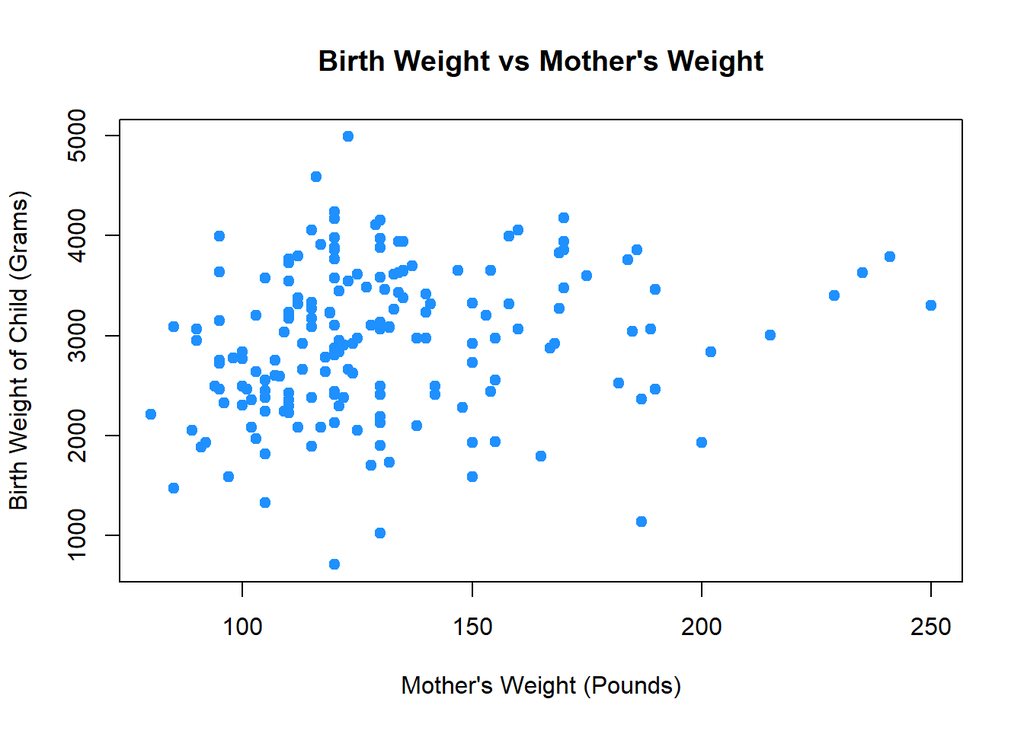

```r
plot(bwt ~ lwt, data = birthwt,xlab = "Mother's Weight (Pounds)",ylab = "Birth Weight of Child (Grams)",main = "Birth Weight vs Mother's Weight",pch = 20,cex = 1.5,col = "dodgerblue")
```

**(c)** Create a scatter plot of birth weight (y-axis) vs mother’s age (x-axis). Use a non-default color for the points. (Also, be sure to give the plot a title and label the axes appropriately.) Based on the scatter plot, does there seem to be a relationship between the two variables? Briefly explain.

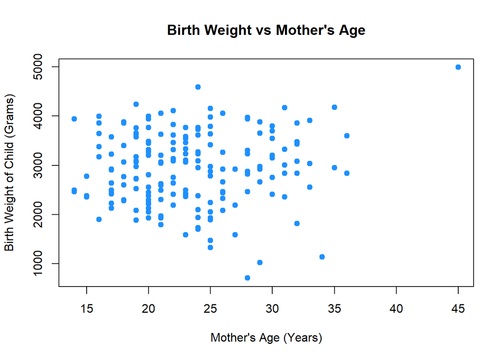

```r
plot(bwt ~ age, data = birthwt,xlab = "Mother's Age (Years)",ylab = "Birth Weight of Child (Grams)",main = "Birth Weight vs Mother's Age",pch = 20,cex = 1.5,col = "dodgerblue")
```

**(d)** Create side-by-side boxplots for birth weight grouped by smoking status. Use non-default colors for the plot. (Also, be sure to give the plot a title and label the axes appropriately.) Based on the boxplot, does there seem to be a difference in birth weight for mothers who smoked? Briefly explain.

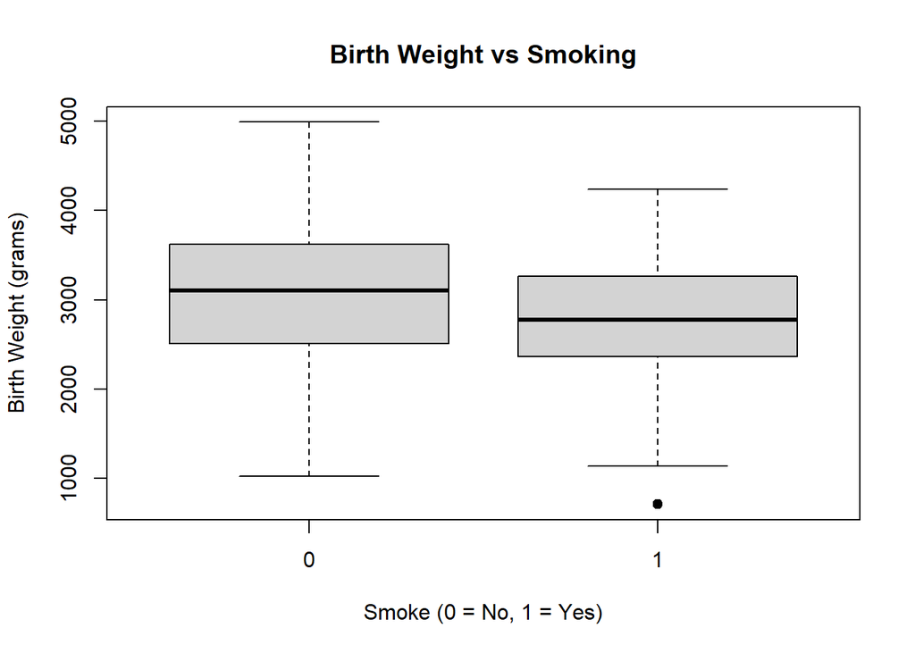

```r
boxplot(bwt ~ smoke, data = birthwt,xlab = "Smoke (0 = No, 1 = Yes)",ylab = "Birth Weight (grams)",main = "Birth Weight vs Smoking",pch = 20,cex = 1.5)
```

**Babies born to mothers who smoke seems to have an average less weight compared to non smoking mothers.**

## Exercise 3 (Importing Data, More Plotting)

For this exercise we will use the data stored in nutrition-2018.csv. It contains the nutritional values per serving size for a large variety of foods as calculated by the USDA in 2018. It is a cleaned version totaling 5956 observations and is current as of April 2018.

**(a)** Create a histogram of Calories. Do not modify R’s default bin selection. Make the plot presentable. Describe the shape of the histogram. Do you notice anything unusual?

```r
library(readr)
nutrition =read_csv("nutrition-2018.csv")
```

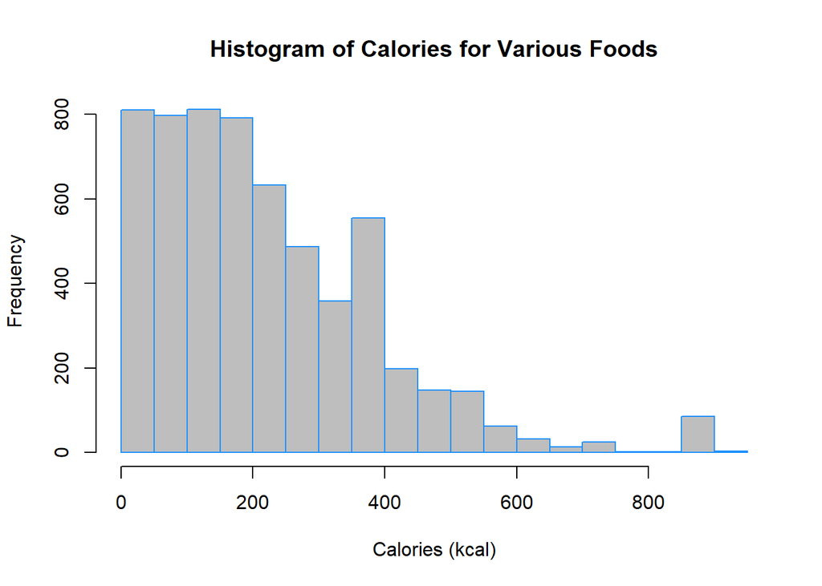

```r
hist(nutrition$Calories,xlab = "Calories (kcal)",main = "Histogram of Calories for Various Foods",border = "dodgerblue",col = "grey")
```

**This histogram is skewed, we see more frequencies when calories are less compared to more calories. There are couple of exception like 400cal and one past 800 cal.**

**(b)** Create a scatter plot of calories (y-axis) vs protein (x-axis). Make the plot presentable. Do you notice any trends? Do you think that knowing only the protein content of a food, you could make a good prediction of the calories in the food?

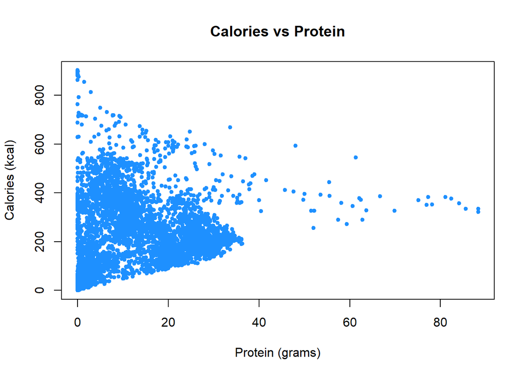

```r
plot(nutrition$Calories ~ nutrition$Protein, xlab = "Protein (grams)",ylab = "Calories (kcal)",main = "Calories vs Protein",pch = 20,cex = 1,col = "dodgerblue")
```

**(c)** Create a scatter plot of Calories (y-axis) vs 4 * Protein + 4 * Carbs + 9 * Fat (x-axis). Make the plot presentable. You will either need to add a new variable to the data frame, or use the I() function in your formula in the call to plot(). If you are at all familiar with nutrition, you may realize that this formula calculates the calorie count based on the protein, carbohydrate, and fat values. You’d expect then that the result here is a straight line. Is it? If not, can you think of any reasons why it is not?

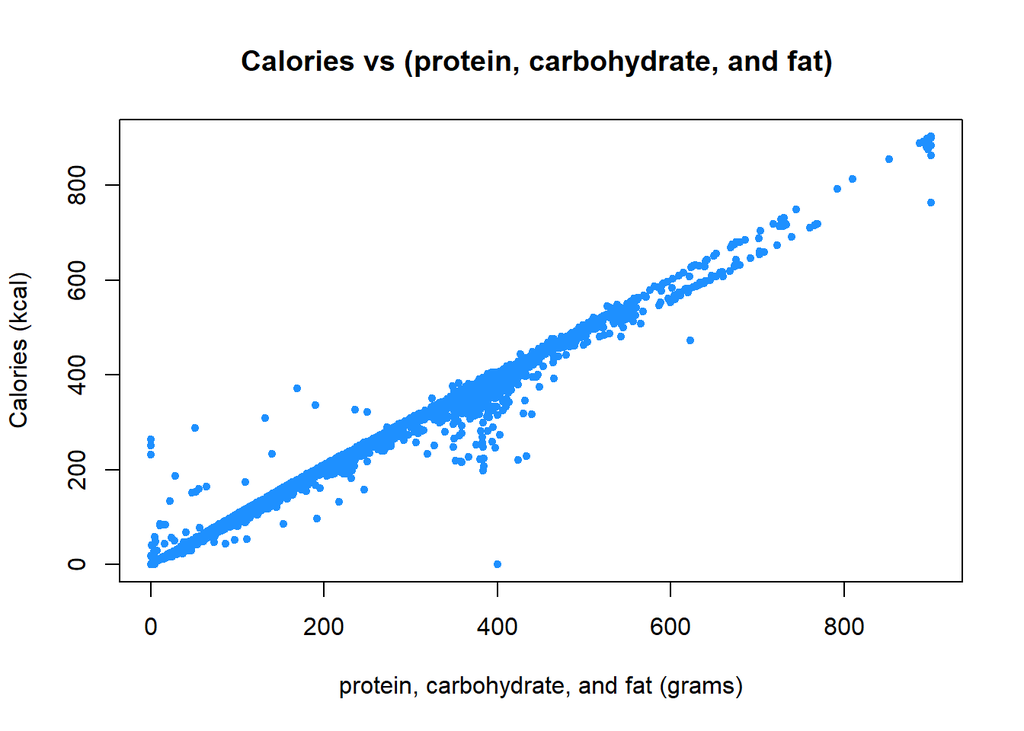

```r
plot(Calories ~ I(4 * Protein + 4 * Carbs + 9 * Fat), data = nutrition,xlab = "protein, carbohydrate, and fat (grams)",ylab = "Calories (kcal)",main = "Calories vs (protein, carbohydrate, and fat) ",pch = 20,cex = 1,col = "dodgerblue")
```

**This is not an exact straight line. There are few outliers and a thick line which can be because there can be other factors besides Protein, carbohydrates and fats which contribute to calories.**

## Exercise 4 (Writing and Using Functions)

**(a)** Write a function called sum_of_squares. • Arguments: – A vector of numeric data x • Output: – The sum of the squares of the elements of the vector ni=1 x2i Provide your function, as well as the result of running the following code: sum_of_squares(x = a) sum_of_squares(x = c(c, d))

```r
a = 1:10
b = 10:1
c = rep(1, times = 10)
d =2 ^ (1:10)
sum_of_squares = function(x) {
    sum(x ^ 2)
    }
sum_of_squares(x = a)
```

```
## [1] 385
```

```r
sum_of_squares(x = c(c, d))
```

```
## [1] 1398110
```

```r
sqrt(sum_of_squares(d - 0) / length(d))
```

```
## [1] 373.9118
```

```r
sqrt(sum_of_squares(a - b) / length(a - b))
```

```
## [1] 5.744563
```

## Exercise 5 (More Writing and Using Functions)

For each of the following parts, use the following vectors: set.seed(42) x = 1:100 y = rnorm(1000) z = runif(150, min = 0, max = 1)

**(a)** Write a function called list_extreme_values. • Arguments: – A vector of numeric data x – A positive constant, k, with a default value of 2 • Output: – A list with two elements: small, a vector of elements of x that are k sample standard deviations less than the sample mean. That is, the observations that are smaller than x ̄ − k · s. large, a vector of elements of x that are k sample standard deviations greater than the sample mean. That is, the observations that are larger than x ̄ + k · s.

Provide your function, as well as the result of running the following code: list_extreme_values(x = x, k = 1) list_extreme_values(x = y, k = 3) list_extreme_values(x = y, k = 2) list_extreme_values(x = z, k = 1.5)

```r
set.seed(42)
x = 1:100
y = rnorm(1000)
z = runif(150, min = 0, max = 1)

list_extreme_values = function(x, k = 2) {
    x_bar =mean(x)
    s =sd(x)
    list(
        small = x[x < x_bar - k * s],
        large = x[x > x_bar + k * s])
    }
list_extreme_values(x = x, k = 1)
```

```
## $small
##  [1]  1  2  3  4  5  6  7  8  9 10 11 12 13 14 15 16 17 18 19 20 21
##
## $large
##  [1]  80  81  82  83  84  85  86  87  88  89  90  91  92  93  94  95  96  97  98
## [20]  99 100
```

```r
list_extreme_values(x = y, k = 3)
```

```
## $small
## [1] -3.371739
##
## $large
## [1] 3.229069 3.211199 3.495304
```

```r
list_extreme_values(x = y, k = 2)
```

```
## $small
##  [1] -2.656455 -2.440467 -2.414208 -2.993090 -2.699930 -2.113200 -2.188835
##  [8] -2.071388 -2.138368 -2.461335 -2.170247 -3.017933 -2.192786 -2.253132
## [15] -2.277778 -2.292971 -2.206485 -2.553825 -2.082814 -2.958780 -2.136025
## [22] -2.183149 -3.371739
##
## $large
##  [1] 2.018424 2.286645 2.701891 2.059539 2.036972 2.049961 2.459594 2.212055
##  [9] 2.422163 2.019891 2.965865 2.098031 2.241904 2.041313 3.229069 2.223534
## [17] 3.211199 2.623495 2.727196 2.178668 3.495304
```

```r
list_extreme_values(x = z, k = 1.5)
```

```
## $small
## [1] 0.001703130 0.077464589 0.047054933 0.060877148 0.009629518 0.004321658
## [7] 0.028495955 0.005327612 0.041129370
##
## $large
##  [1] 0.9899656 0.9521815 0.9741261 0.9474009 0.9586979 0.9756436 0.9954564
##  [8] 0.9517322 0.9342643 0.9310075
```

**(b)**Using only your function list_extreme_values(), mean(), and basic list operations, calculate the mean of observations that are greater than 1.5 standard deviation above the mean in the vector y.

```r
mean(list_extreme_values(x = y, k = 1.5)$large)
```

```
## [1] 1.970506
```